# Part I - (Prosper Loan Data Presentation)

## by (David Karanja Mwangi)

## Investigation Overview

The goal of this Exploration is to understand how the Loan Term is influenced by other factors or attributes about the loan and the client. An exploration into the estimated returns and estimated losses associated with different loan Terms. The geograhic location of borrowers and whether they own homes or not.

## Dataset Overview

The Prosper loan data set contains 113,937 loans with 81 variables on each loan, including

- loan amount,
- borrower rate (or interest rate),
- current loan status,
- borrower income, and many others.

### Loan Term Popularity

The most popular loan term is 36 months (87778) while the least common is 12 (1614). 36 months loan term is more than 3 times the 60 months loan term. 60 months loan term has (24545) records.

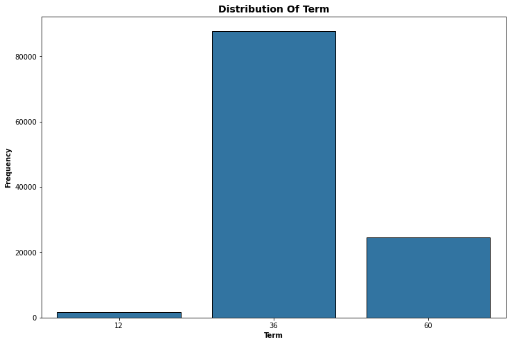

### States where people are most likely to take prosper loans and viceversa

California State has the largest number of borrowers which stands at over 14,000. North Dakota state on the contrary has the least number, 52. However, we would need population information to be able to do some feature engineering to decide states with the highest loan uptake rate.

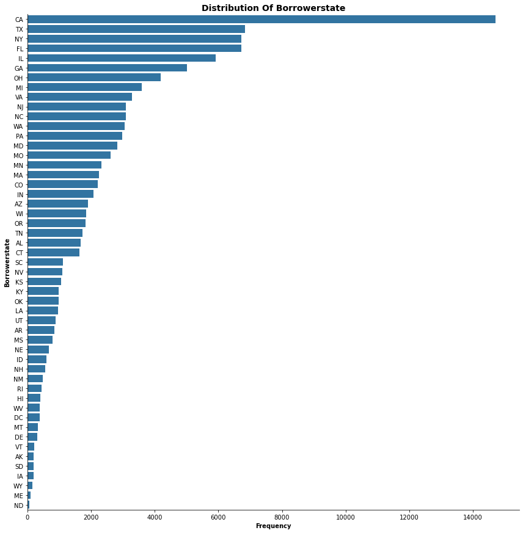

### Percentage of borrowers with homes

Borrowers are almost split into half. Both those with homes and those without are taking loans. 49.6% do not have mortgages while 50.4% of borrowers have mortgages.

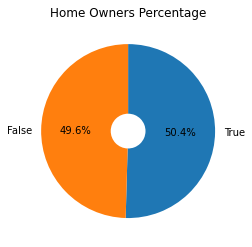

### How does the estimated loss compare among the three loan terms?

Estimated Loss for loans at 12 month terms are low compared to the estimated loss for 36 month Term loans. A couple of outliers are also observed in the 36 month term.

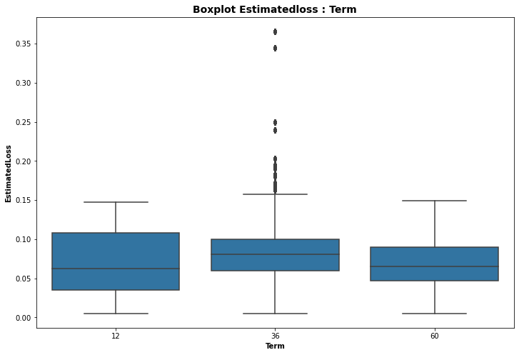